# EDA Assignment 4 - COVID-19 Visualisation

Brenden Taylor

11/05/2020

# Written Piece

COVID-19 has, in the literal sense, gone viral this year. Every day, we see graphs and infographics, news articles and interviews, and it’s often quite difficult making sense of these sources of information. This has lead to a rise in ‘Facebook Virologists’ and ‘WhatsApp Journalists’ who spread news far and wide without fully understanding it, or knowing where it came from. Particularly now, during a global pandemic, this is dangerous and irresponsible (see [the bleach cure](https://www.bbc.com/news/world-us-canada-52407177)).Today we’re going to unpack what we think are two of the more useful animations, and also point out some things you need to be careful of when interpreting any these.

Before we take a look at some graphics though, it’s important to know that comparisons between countries are generally not as straight forward as one might think. Different countries are just that - different! They have different populations with different socio-economic circumstances, different economies, different healthcare systems and different priorities. These differences make it very difficult to accurately compare the impact of COVID-19 in multiple countries and we need to be aware of this. For example, one shouldn’t be suprised to find out that the USA has way more deaths due to the virus than New Zealand. Firstly, the US has a population far greater than New Zealand’s. Secondly, the US has more confirmed cases. Thirdly, the US had its first case before New Zealand so the virus has had more time to run its course in the US.

Of course, comparisons can still be made but we just need to be aware that there are differences and it might be one of these underlying differences that explains something, not what we think it is! In fact, it’s important that we do still make comparisons in order to try and learn from the experiences of other countries.

## The Map

The first animation is the classic map.

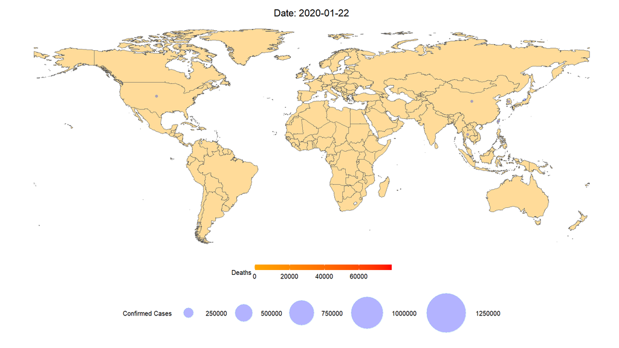

This is one of the nicer animations out there simply because it can show a fair amount of information, while still being quite easily intepreted.

Firstly, we can see that the title is running through dates so we know that the picture is changing as time goes on (this is pretty much always the case for COVID-19 GIFs because that’s what we want to see: how things change over time!). Secondly, we need to take careful note of the legends so we can get a better understanding of what this GIF is showing us. In this case, there are two legends. The colour scale shows us the number of deaths in a country while the size of the circle over a country indicates the number of confirmed cases.

Based on this animation, we can see there was a fairly long period where only a handful of countries had confirmed cases of the virus. After this period though, the virus quickly spreads through Europe and then through Africa and South America. This confirms that countries with lots of international travel were more likely to develop cases before countries without international travel.

It’s also interesting to note that there are a few countries in Europe, like Spain and Italy, that start turning red (indicating increasing deaths) despite having significantly fewer confirmed cases than the US. This could point to some underlying circumstances that mean the fatality rate of the virus is slightly higher in these countries than in the US. This could be due to worse healthcare, a prevalence of pre-existing medical conditions in the population or a more aged population.

We can also see that the US has confirmed significantly more cases that any other country. As mentioned earlier, we must be careful when trying to explain why this is. Not surprisingly (see below), the more cases the US develops, the faster even more cases develop.

Lastly, there doesn’t appear to be a single country without a blue dot by the end of the GIF i.e. virtually every country has reported at least one case of the virus.

## The Area Graph

[figure not shown]

We can see that the x-axis shows the date and the y-axis shows a number. Based on the legend, we know that this graph is showing us the number of confirmed cases, deaths and recoveries as time goes on. Very importantly, these types of graphs are stacked. Basically, there is no section of red (confirmed cases) that’s covered by yellow (deaths) - the red area is stacked on top of the yellow and green areas. This allows us to easily compare proportions. In this case, we can see that there are significantly more recoveries than deaths - which is good! We can also see that the deaths only really started increasing around the beginning of April.

When it comes to this type of graph (or especially a line graph), we often hear the term “exponential” along with it. This means that the growth in number of confirmed cases/deaths/recoveries is increasing at a faster and faster rate every day. When you think about it, this makes sense: if you start with 1 infection and that person infects 3 others, then those 3 go on to infect 3 more and so on. Pretty soon you’ve got thousands of infections!

In this case, we can clearly see the exponential shape, particularly in the number of confirmed cases. It’s interesting to note that the curve stays fairly flat until about mid-March, where it starts to really pick up quite quickly. If we take a look back at the map, we can see that around mid-March is when the virus started appearing in lots of countries, which makes sense. This also seems to confirm the roughly 2-week recovery period since recoveries seem to start increasing significantly about 2 weeks later, in the beginning of April.

One thing that’s important to note with this graph is that confirmed cases, deaths and recoveries aren’t actually happening all at the same time, as the graph seems to suggest. Recovering from COVID-19 can take up to two weeks so the number of recoveries reported today is actually linked to the number of confirmed cases reported any time between today and two weeks ago, and the same is true for deaths. This probably leads to a slightly higher recovery rate than this graph seems to suggest but also a slightly higher mortality rate! It also explains why the number of deaths plus the number of recoveries does not equal the number of confirmed cases - there are still some ‘active’ cases.

## Last Remarks

While there are many graphics out there on COVID-19, it’s important that they are understood correctly. Many visualisations actually have more to say than it first seems but they can also be misleading if not properly analysed.